# Update

author: Richèl J.C. Bilderbeek date: 2021-07-15 autosize: true

https://github.com/richelbilderbeek/igp_presentation_20210715

# Setup

- Publishing strategy
- Describe GCAE
- Share proof of concept results
  - Spoiler: the encouraging results are rather contrived
  - Could use ideas here

# Publishing strategy

| Publication model | Classical | Registered report |
| --- | --- | --- |
| Significant results | Can publish | Can publish |
| No significant results | Cannot publish | Can publish |

> Publication pressure was associated with higher odds of engaging frequently in ≥1 QRP (OR 1.22, 95% CI: 1.14, 1.30)

Gopalakrishna, G., Riet, G. t., Cruyff, M. J., Vink, G., Stoop, I., Wicherts, J. M., & Bouter, L. (2021, July 6). Prevalence of questionable research practices, research misconduct and their potential explanatory factors: a survey among academic researchers in The Netherlands. https://doi.org/10.31222/osf.io/vk9yt

# Introduction

Quantitive trait associations, e.g. protein levels, are important.

Works well when:

- 1 SNP -> 1 phenotype, e.g PLINK
- More SNPs linearly determine a phenotype, e.g. SKAT

# Research question

Can we find novel associations using machine learning?

Novel == un(der)detected using existing methods

[figure not shown]

# Problem

- Dimensionality reduction
- PCA is linear, where data is complex
- Deep learning learn non-linear and complex features

# PCA is useful

Lao, Oscar, et al. “Correlation between genetic and geographic structure in Europe.” Current Biology 18.16 (2008): 1241-1248.

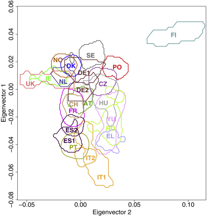

Lao et al., 2008 figure 1

# Potential to do better than PCA

Ausmees, Kristiina and Nettelblad, Carl. “A deep learning framework for characterization of genotype data.” bioRxiv (2020)

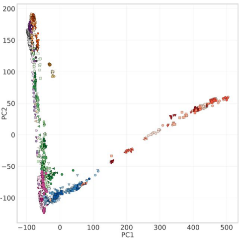

Ausmees and Nettelblad, 2020 figure 3a

# Do better than PCA using GCAE

Ausmees, Kristiina and Nettelblad, Carl. “A deep learning framework for characterization of genotype data.” bioRxiv (2020)

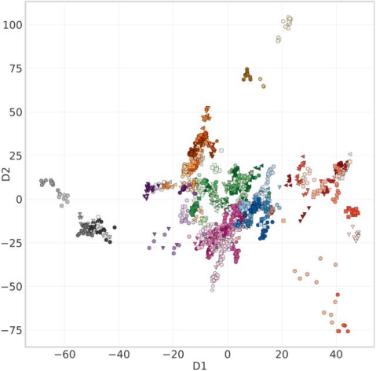

Ausmees and Nettelblad, 2020 figure 3b

# GCAE

| Character | Full | What |
| --- | --- | --- |
| G | Genomic | Works on genomic data |
| C | Convolutional | Works on processed data |
| A | Auto | Learns by itself |
| E | Encoder | to efficiently encode the data |

# Type of analysis

- Prediction and association
- Quantitative and binary traits

# Research question

Can we find novel associations using GCAE?

Novel == un(der)detected using existing methods

[figure not shown]

# State of GCAE now

- Does not yet allow a trait to be encoded along genotype

# Finding novel associations

Proof of concept:

- No association
- Additive association
- XOR
- EXP
- Your suggestion

```r
library(plinkr)
set.seed(314)
mafs <- 0.49
n_individuals <- 1000
```

# Random phenotype

A phenotype that is completely unrelated to the SNPs investigated

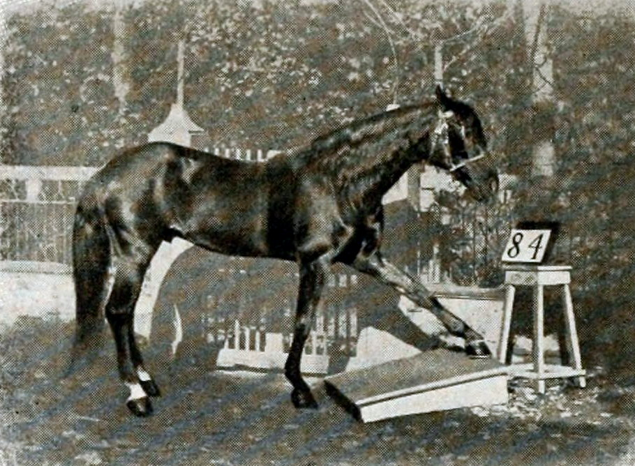

https://upload.wikimedia.org/wikipedia/commons/6/6c/Hans_am_Tretbrett.jpg

# Random phenotype

class: small-code

```r
snvs <- create_snvs(
  n_individuals = 4
)
calc_random_phenotype <- function(snvs) {
  stats::runif(nrow(snvs))
}
snvs$random <- calc_random_phenotype(snvs)
```

```r
knitr::kable(snvs)
```

| snv_1a | snv_1b | random |
| --- | --- | --- |
| A | A | 0.0988320 |
| A | C | 0.2714778 |
| C | A | 0.7665282 |
| C | C | 0.2246424 |

# Random trait

class: small-code

```r
random_trait <- create_custom_trait(
  phenotype = "random",
  mafs = 0.49,
  n_snps = 1,
  calc_phenotype_function =
    calc_random_phenotype
)
random_data <- create_demo_assoc_qt_params(
  traits = random_trait,
  n_individuals = n_individuals
)
```

```r
knitr::kable(
  cbind(
    random_data$ped_table[, -seq(1, 6)],
    random_data$phe_table[, 3]
  )
)
```

| snv_1a | snv_1b | random |
| --- | --- | --- |
| C | C | 0.4666161 |
| C | C | 0.3510843 |
| A | A | 0.9266955 |
| C | A | 0.9974184 |
| C | C | 0.4981833 |
| C | C | 0.4371469 |
| C | C | 0.3710171 |
| A | A | 0.4765347 |
| C | A | 0.8747569 |
| A | A | 0.0703521 |
| C | A | 0.5177573 |
| A | C | 0.7403552 |
| C | A | 0.6766470 |
| C | C | 0.3195054 |
| A | C | 0.6527457 |
| C | C | 0.2545512 |
| A | A | 0.4073478 |
| C | A | 0.8687714 |
| A | C | 0.9359008 |
| A | C | 0.7342456 |
| C | C | 0.4629348 |
| C | A | 0.9954340 |
| A | C | 0.4298082 |
| C | A | 0.5565240 |
| A | C | 0.2405035 |
| A | A | 0.2429802 |
| C | A | 0.4378420 |
| A | C | 0.9054450 |
| C | C | 0.0004699 |
| A | C | 0.5640251 |

[output cut: 970 more lines]

# Associations on random data

```r
knitr::kable(assoc_qt(random_data))
```

| CHR | SNP | BP | NMISS | BETA | SE | R2 | T | P |
| --- | --- | --- | --- | --- | --- | --- | --- | --- |
| 1 | snp_1 | 1 | 1000 | 0.01843 | 0.01278 | 0.002079 | 1.442 | 0.1496 |

No association is correctly detected.

# Additive phenotype

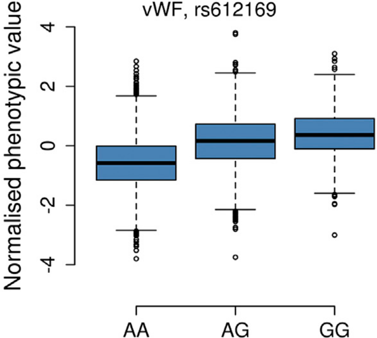

https://doi.org/10.1016/j.ajhg.2015.01.001

```r
snvs <- create_snvs(
  n_individuals = 4
)
calc_additive_phenotype <- function(snvs) {
  (rowSums(snvs == "C") / 10.0) +
    runif(nrow(snvs), min = 0.0, max = 0.01)
}
snvs$additive <- calc_additive_phenotype(snvs)
```

```r
knitr::kable(snvs)
```

| snv_1a | snv_1b | additive |
| --- | --- | --- |
| A | A | 0.0038967 |
| A | C | 0.1040717 |
| C | A | 0.1007025 |
| C | C | 0.2061279 |

# Additive trait

class: small-code

```r
additive_trait <- create_custom_trait(
  phenotype = "additive",
  mafs = 0.49,
  n_snps = 1,
  calc_phenotype_function =
    calc_additive_phenotype
)
additive_data <- create_demo_assoc_qt_params(
  traits = additive_trait,
  n_individuals = n_individuals
)
```

```r
knitr::kable(
  cbind(
    additive_data$ped_table[, -seq(1, 6)],
    additive_data$phe_table[, 3]
  )
)
```

| snv_1a | snv_1b | additive |
| --- | --- | --- |
| C | C | 0.2001345 |
| A | A | 0.0035830 |
| C | A | 0.1023847 |
| C | A | 0.1053521 |
| A | A | 0.0005797 |
| C | A | 0.1069706 |
| A | C | 0.1089242 |
| A | A | 0.0018606 |
| A | A | 0.0006008 |
| A | C | 0.1050057 |
| C | A | 0.1084381 |
| A | C | 0.1023191 |
| C | C | 0.2030954 |
| A | A | 0.0059369 |
| C | C | 0.2033870 |
| A | C | 0.1099877 |
| A | C | 0.1014320 |
| A | A | 0.0080159 |
| A | A | 0.0022211 |
| C | A | 0.1028064 |
| A | A | 0.0023147 |
| C | C | 0.2085766 |
| C | C | 0.2092915 |
| C | A | 0.1077363 |
| A | C | 0.1060595 |
| A | C | 0.1000014 |
| A | C | 0.1096937 |
| C | C | 0.2041953 |
| C | C | 0.2011429 |
| C | C | 0.2035675 |

[output cut: 970 more lines]

# Associations on additive data

```r
knitr::kable(assoc_qt(additive_data))
```

| CHR | SNP | BP | NMISS | BETA | SE | R2 | T | P |
| --- | --- | --- | --- | --- | --- | --- | --- | --- |
| 1 | snp_1 | 1 | 1000 | 0.1001 | 0.0001307 | 0.9983 | 766.1 | 0 |

Additive associations are detected awesomely!

# Exclusive-or phenotype

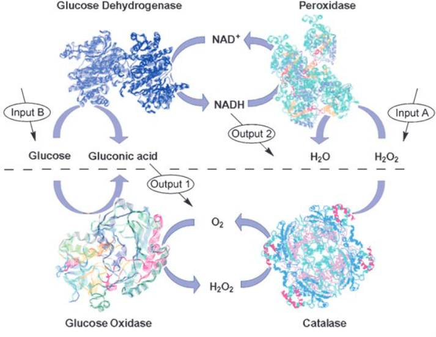

Baron, Ronan, et al. “Elementary arithmetic operations by enzymes: A model for metabolic pathway based computing.” Angewandte Chemie International Edition 45.10 (2006): 1572-1576.

# Exclusive-or phenotype

class: small-code

```r
snvs <- create_snvs(
  n_snps = 2,
  n_individuals = 16
)
calc_xor_phenotype <- function(snvs) {
  if (ncol(snvs) < 4) {
    return(
      rep(3.14, nrow(snvs))
    )
  }
  0.1 * (snvs$snv_1a == snvs$snv_1b &
    snvs$snv_1a != snvs$snv_2a &
    snvs$snv_2a == snvs$snv_2b
  )
}
snvs$xor <- calc_xor_phenotype(snvs)
```

```r
knitr::kable(snvs)
```

| snv_1a | snv_1b | snv_2a | snv_2b | xor |
| --- | --- | --- | --- | --- |
| A | A | A | A | 0.0 |
| A | A | A | C | 0.0 |
| A | A | C | A | 0.0 |
| A | A | C | C | 0.1 |
| A | C | A | A | 0.0 |
| A | C | A | C | 0.0 |
| A | C | C | A | 0.0 |
| A | C | C | C | 0.0 |
| C | A | A | A | 0.0 |
| C | A | A | C | 0.0 |
| C | A | C | A | 0.0 |
| C | A | C | C | 0.0 |
| C | C | A | A | 0.1 |
| C | C | A | C | 0.0 |
| C | C | C | A | 0.0 |
| C | C | C | C | 0.0 |

# Exclusive-or (XOR) trait

class: small-code

```r
xor_trait <- create_custom_trait(
  phenotype = "xor",
  mafs = 0.49,
  n_snps = 2,
  calc_phenotype_function =
    calc_xor_phenotype
)
xor_data <- create_demo_assoc_qt_params(
  traits = xor_trait,
  n_individuals = n_individuals
)
```

```r
knitr::kable(
  cbind(
    xor_data$ped_table[, -seq(1, 6)],
    xor_data$phe_table[, 3]
  )
)
```

| snv_1a | snv_1b | snv_2a | snv_2b | xor |
| --- | --- | --- | --- | --- |
| C | A | C | A | 0.0 |
| C | A | C | A | 0.0 |
| C | A | A | A | 0.0 |
| C | A | A | C | 0.0 |
| A | A | A | C | 0.0 |
| C | C | C | A | 0.0 |
| C | A | A | A | 0.0 |
| A | A | A | A | 0.0 |
| A | C | A | A | 0.0 |
| C | C | C | C | 0.0 |
| C | C | A | C | 0.0 |
| C | C | C | A | 0.0 |
| A | C | A | C | 0.0 |
| C | C | A | A | 0.1 |
| C | C | C | A | 0.0 |
| C | C | A | C | 0.0 |
| A | C | C | A | 0.0 |
| C | A | A | C | 0.0 |
| C | C | C | A | 0.0 |
| A | C | A | C | 0.0 |
| C | C | C | A | 0.0 |
| C | A | C | C | 0.0 |
| A | C | A | A | 0.0 |
| C | C | C | C | 0.0 |
| C | C | A | A | 0.1 |
| A | A | A | C | 0.0 |
| C | C | C | C | 0.0 |
| A | A | A | A | 0.0 |
| A | C | C | C | 0.0 |
| A | A | A | A | 0.0 |

[output cut: 970 more lines]

# Associations on exclusive-or (XOR) data

```r
knitr::kable(assoc_qt(xor_data))
```

| CHR | SNP | BP | NMISS | BETA | SE | R2 | T | P |
| --- | --- | --- | --- | --- | --- | --- | --- | --- |
| 1 | snp_1 | 1 | 1000 | 0.0005299 | 0.001523 | 0.0001212 | 0.3479 | 0.7280 |
| 2 | snp_2 | 2 | 1000 | 0.0004813 | 0.001452 | 0.0001101 | 0.3315 | 0.7403 |

- XOR cannot be detected
- Very artificial example

# ML can do exclusive-or (XOR)

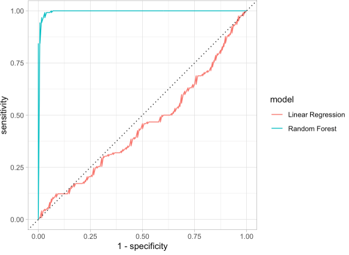

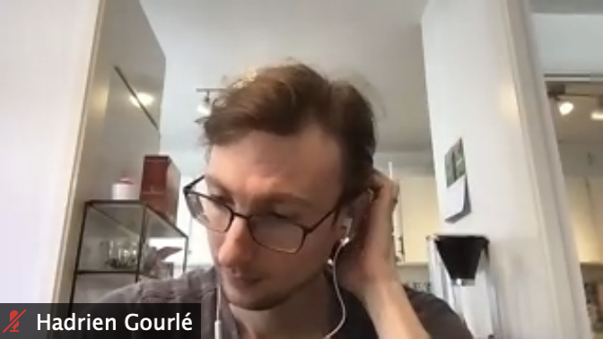

# Exponential phenotype

Exponential

# Exponential phenotype

class: small-code

```r
snvs <- create_snvs(
  n_snps = 3,
  n_individuals = 16
)
calc_exp_phenotype <- function(snvs) {
  as <- seq(1, ncol(snvs), by = 2)
  bs <- as + 1
  h <- snvs[, as] == snvs[, bs] & snvs[, as] == "C"
  10 ^ rowSums(h)
}
snvs$exp <- calc_exp_phenotype(snvs)
```

```r
knitr::kable(snvs)
```

| snv_1a | snv_1b | snv_2a | snv_2b | snv_3a | snv_3b | exp |
| --- | --- | --- | --- | --- | --- | --- |
| A | A | A | A | A | A | 1 |
| A | A | A | A | A | C | 1 |
| A | A | A | A | C | A | 1 |
| A | A | A | A | C | C | 10 |
| A | A | A | C | A | A | 1 |
| A | A | A | C | A | C | 1 |
| A | A | A | C | C | A | 1 |
| A | A | A | C | C | C | 10 |
| A | A | C | A | A | A | 1 |
| A | A | C | A | A | C | 1 |
| A | A | C | A | C | A | 1 |
| A | A | C | A | C | C | 10 |
| A | A | C | C | A | A | 10 |
| A | A | C | C | A | C | 10 |
| A | A | C | C | C | A | 10 |
| A | A | C | C | C | C | 100 |

# Exponential trait

class: small-code

```r
exp_trait <- create_custom_trait(
  phenotype = "exp",
  mafs = 0.49,
  n_snps = 8,
  calc_phenotype_function =
    calc_exp_phenotype
)
exp_data <- create_demo_assoc_qt_params(
  traits = exp_trait,
  n_individuals = n_individuals
)
```

```r
knitr::kable(
  cbind(
    exp_data$ped_table[, -seq(1, 18)],
    exp_data$phe_table[, 3]
  )
)
```

[output not shown]

[output cut: 970 more lines]

# Associations on exp data

```r
knitr::kable(assoc_qt(exp_data))
```

| CHR | SNP | BP | NMISS | BETA | SE | R2 | T | P |
| --- | --- | --- | --- | --- | --- | --- | --- | --- |
| 1 | snp_1 | 1 | 1000 | 8780 | 2889 | 0.0091700 | 3.0390 | 0.0024340 |
| 2 | snp_2 | 2 | 1000 | 4418 | 2881 | 0.0023510 | 1.5330 | 0.1255000 |
| 3 | snp_3 | 3 | 1000 | 8600 | 2866 | 0.0089410 | 3.0010 | 0.0027610 |
| 4 | snp_4 | 4 | 1000 | 7132 | 2836 | 0.0062980 | 2.5150 | 0.0120600 |
| 5 | snp_5 | 5 | 1000 | 2470 | 2861 | 0.0007464 | 0.8634 | 0.3881000 |
| 6 | snp_6 | 6 | 1000 | 10940 | 2802 | 0.0150400 | 3.9040 | 0.0001011 |
| 7 | snp_7 | 7 | 1000 | 9149 | 2882 | 0.0099980 | 3.1750 | 0.0015460 |
| 8 | snp_8 | 8 | 1000 | 10860 | 2888 | 0.0139800 | 3.7620 | 0.0001785 |

# Features of examples

- Pro: Clear, simple structure
- Con: Artificial, lacks complex structure

# Your example

Could you come up with

- a biologically (more) relevant example
- that fails now
- with a complex structure
- that would convince you of GCAE

I’ll be happy try it!

# Conclusion

- GCAE appears promising, yet needs work
- Could use a more convincing proof of concept